# The Performance Analysis of NBN100 Broadband Plan of Retail Service Providers in New South Wales

Project 3

510611635

University of Sydney | DATA1901 | May 2022

# 1 Recommendation

The clients of the report are New South Wales citizens who are looking for NBN100 broadband plans.

# 2 Evidence

```r
# Load packages
library(tidyverse)

# Read in the dataset from the url
broadband = read.csv("http://www.maths.usyd.edu.au/u/UG/JM/DATA1001/r/current/projects/2022data/broadband.csv", na.strings = c("", "NA"))
```

According to the dataset, 50/20 Mbps and 100/40 Mbps are two of the most used NBN speed tier of the service. Hence this report will focus these two tiers and compare the performance of Telstra to other RSPs.

## 2.1 Speed Analysis

```
## # A tibble: 10 × 5
##    rsp              median_dl_speed median_ul_speed median_lat median_out
##    <chr>                      <dbl>           <dbl>      <dbl>      <dbl>
##  1 Aussie Broadband            99.6            37.4       9.36       0.08
##  2 Dodo & iPrimus              94.3            37.4      11.9        0.05
##  3 Exetel                     104.             37.4       9.59       0.07
##  4 iiNet                       94.1            37.6       6.94       0
##  5 MyRepublic                 107.             38.8      11.5        0.15
##  6 Optus                      107.             37.4       8.31       0.03
##  7 Superloop                  100.             36.8      10.7        0.04
##  8 Telstra                    105.             37.5       8.31       0.04
##  9 TPG                        106.             37.6       8.46       0.07
## 10 Vodafone                    92.4            37.4       8.13       0.07
```

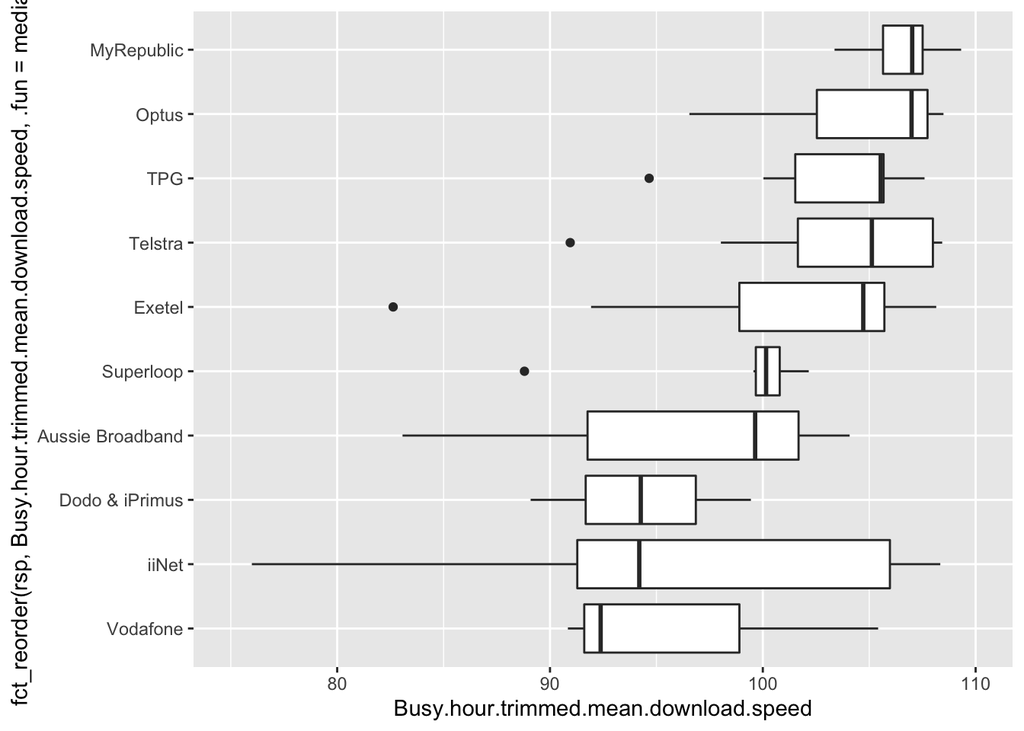

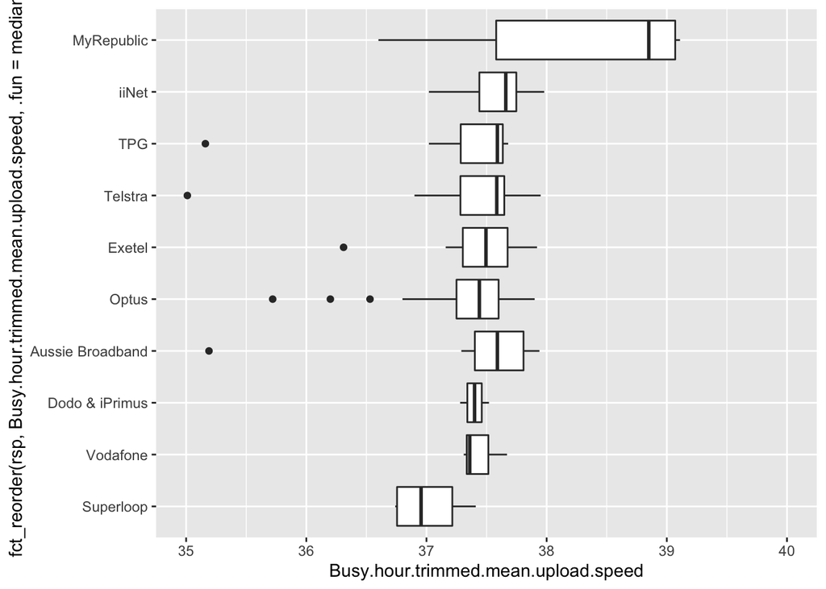

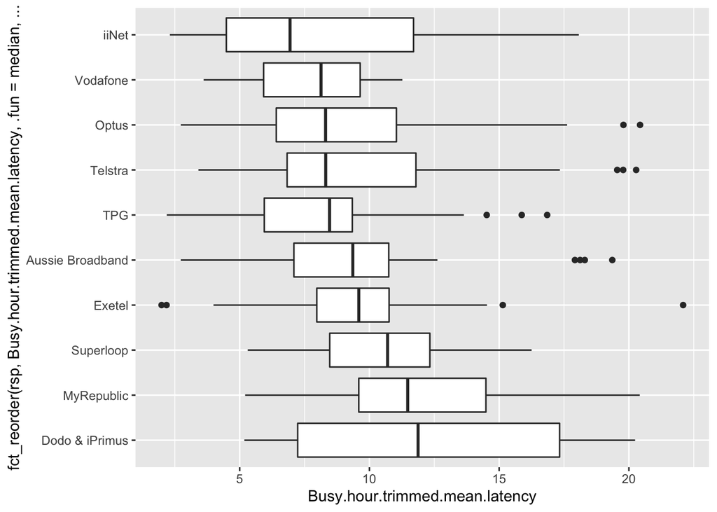

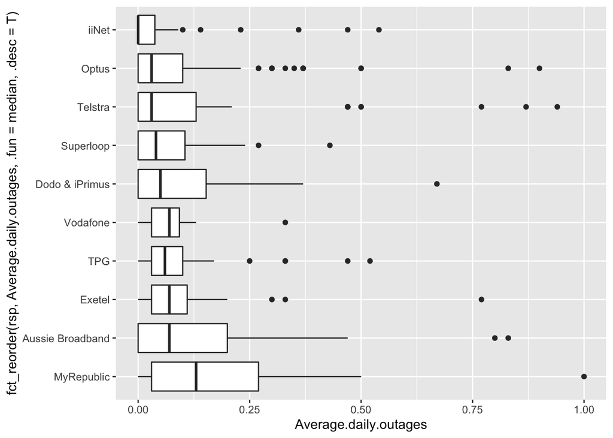

### 2.1.1 50/20 Mbps Speed Tier

```r
# get rows with tier 50/20 Mbps
tier_50_20 = broadband[broadband$tier == "50/20 Mbps", ]
telstra_tier_50_20 = tier_50_20[tier_50_20$rsp == "Telstra", ]
others_tier_50_20 = tier_50_20[tier_50_20$rsp != "Telstra", ]

# median of all hour download speed
t_5020_all_dl_m = round(median(telstra_tier_50_20$All.hour.trimmed.mean.download.speed), 2)
o_5020_all_dl_m = round(median(others_tier_50_20$All.hour.trimmed.mean.download.speed), 2)

# median of busy hour download speed
t_5020_busy_dl_m = round(median(telstra_tier_50_20$Busy.hour.trimmed.mean.download.speed), 2)
o_5020_busy_dl_m = round(median(others_tier_50_20$Busy.hour.trimmed.mean.download.speed), 2)

# median of all hour upload speed
t_5020_all_ul_m = round(median(telstra_tier_50_20$All.hour.trimmed.mean.upload.speed), 2)
o_5020_all_ul_m = round(median(others_tier_50_20$All.hour.trimmed.mean.upload.speed), 2)

# median of busy hour upload speed
t_5020_busy_ul_m = round(median(telstra_tier_50_20$Busy.hour.trimmed.mean.upload.speed), 2)
o_5020_busy_ul_m = round(median(others_tier_50_20$Busy.hour.trimmed.mean.upload.speed), 2)
```

| Categories | Telstra | Other RSPs |
| --- | --- | --- |
| All hour trimmed mean download speed(Mbps) | 53.92 | 53.07 |
| Busy hour trimmed mean download speed(Mbps) | 53.45 | 52.63 |
| All hour trimmed mean upload speed(Mbps) | 18.3 | 18.65 |
| Busy hour trimmed mean upload speed(Mbps) | 18.29 | 18.63 |

The table shows the median of 1% trimmed mean download and upload speed in all and busy hours of 50/20 Mbps tier. For download speed, Telstra is slightly higher than other RSPs. For upload speed, however, Telstra is marginally lower than other RSPs. Besides, the speed drop of Telstra and other RSPs during busy hours is negligible, which indicates the high consistency of broadband speed at the 50/20 Mbps tier.

### 2.1.2 100/40 Mbps Speed Tier

```r
# get rows with tier 100/40 Mbps
tier_100_40 = broadband[broadband$tier == "100/40 Mbps", ]
telstra_tier_100_40 = tier_100_40[tier_100_40$rsp == "Telstra", ]
others_tier_100_40 = tier_100_40[tier_100_40$rsp != "Telstra", ]

# median of all hour download speed
t_10040_all_dl_m = round(median(telstra_tier_100_40$All.hour.trimmed.mean.download.speed), 2)
o_10040_all_dl_m = round(median(others_tier_100_40$All.hour.trimmed.mean.download.speed), 2)

# median of busy hour download speed
t_10040_busy_dl_m = round(median(telstra_tier_100_40$Busy.hour.trimmed.mean.download.speed), 2)
o_10040_busy_dl_m = round(median(others_tier_100_40$Busy.hour.trimmed.mean.download.speed), 2)

# median of all hour upload speed
t_10040_all_ul_m = round(median(telstra_tier_100_40$All.hour.trimmed.mean.upload.speed), 2)
o_10040_all_ul_m = round(median(others_tier_100_40$All.hour.trimmed.mean.upload.speed), 2)

# median of busy hour upload speed
t_10040_busy_ul_m = round(median(telstra_tier_100_40$Busy.hour.trimmed.mean.upload.speed), 2)
o_10040_busy_ul_m = round(median(others_tier_100_40$Busy.hour.trimmed.mean.upload.speed), 2)
```

| Categories | Telstra | Other RSPs |
| --- | --- | --- |
| All hour trimmed mean download speed(Mbps) | 106.79 | 101.02 |
| Busy hour trimmed mean download speed(Mbps) | 104.59 | 100.12 |
| All hour trimmed mean upload speed(Mbps) | 36.94 | 37.29 |
| Busy hour trimmed mean upload speed(Mbps) | 36.55 | 37.11 |

## 2.2 Latency Analysis

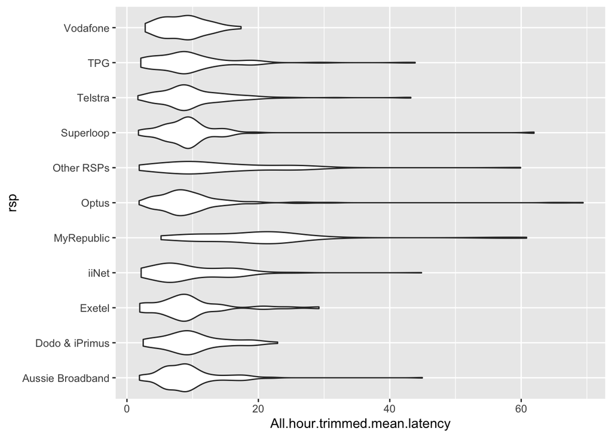

| Categories | Telstra | Other RSPs |
| --- | --- | --- |
| All hour latency(ms) | 9.07 | 8.97 |
| Busy hour latency(ms) | 9.26 | 9.69 |

```r
# median of all hour latency time
t_all_lat_m = round(median(broadband[broadband$rsp == "Telstra", ]$All.hour.trimmed.mean.latency), 2)
o_all_lat_m = round(median(broadband[broadband$rsp != "Telstra", ]$All.hour.trimmed.mean.latency), 2)

# median of busy hour latency time
t_busy_lat_m = round(median(broadband[broadband$rsp == "Telstra", ]$Busy.hour.trimmed.mean.latency), 2)
o_busy_lat_m = round(median(broadband[broadband$rsp != "Telstra", ]$Busy.hour.trimmed.mean.latency), 2)

broadband %>% ggplot(aes(x = rsp, y = All.hour.trimmed.mean.latency)) + geom_violin() + coord_flip()
```

The table shows the median of 1% trimmed mean latency in all and busy hours with all speed tiers combined. For all hour latency, the latency of Telstra is 0.1 $ms$ longer. However, for busy hours, the latency of Telstra is 0.43 $ms$ shorter. This suggests Telstra has more consistent latency than other RSPs.

## 2.3 Outage Analysis

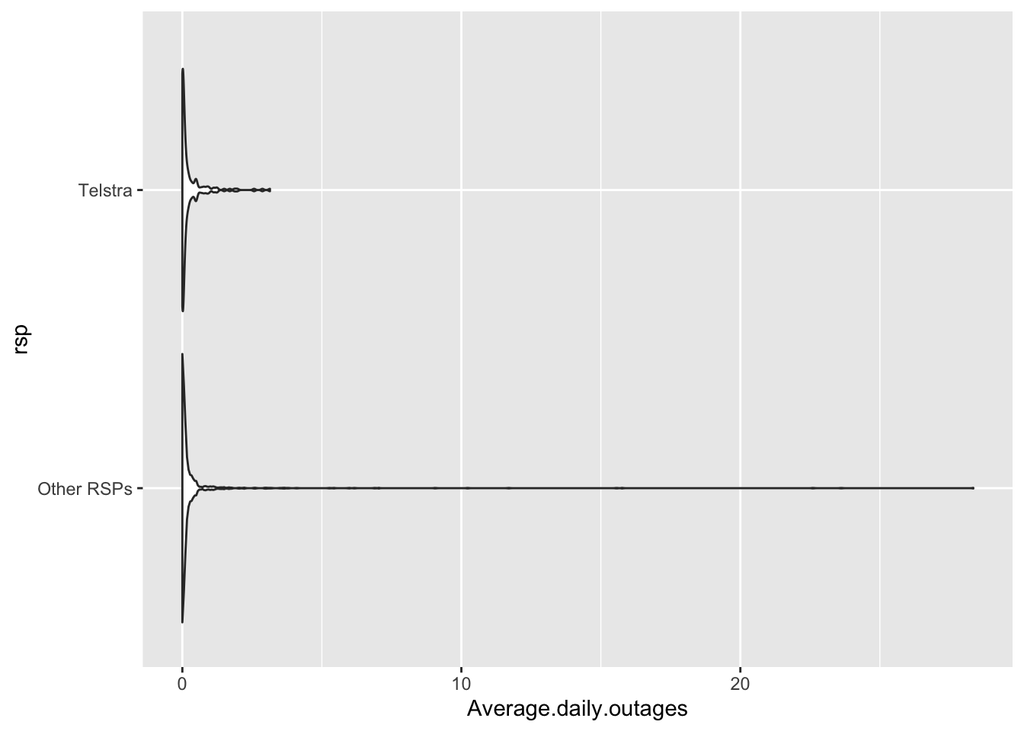

```r
tel = broadband %>% filter(rsp == "Telstra")
t = tel$Average.daily.outages

oth = broadband %>% filter(rsp != "Telstra")
o = oth$Average.daily.outages

broadband %>% mutate(
  rsp = replace(rsp, rsp != "Telstra", "Other RSPs")
) %>% ggplot(aes(x = rsp, y = Average.daily.outages)) + geom_violin() + coord_flip()
```

```r
t_no_out = tel %>% filter(Average.daily.outages == 0) %>% nrow() / tel %>% nrow()
o_no_out = oth %>% filter(Average.daily.outages == 0) %>% nrow() / oth %>% nrow()
```

| Daily outages(times) | Telstra | Other RSPs |
| --- | --- | --- |
| Maximum | 3.14 | 28.35 |
| 3rd quantile | 0.2 | 0.17 |
| Median | 0.04 | 0.07 |
| 1st quantile | 0 | 0 |
| No outage percentage(%) | 39 | 31 |

# 3 Acknowledgments